# GenAI Cybersecurity Review - DRAFT version

# Intro

This is meant as an inventory/tracking on Cybersecurity-related information on the several aspects of GenAI.

This page should evolve over time. It is NOT meant to be either comprehensive nor perfect (or even orderly) in any way or fashion, but instead helps me keep a bit of tracking.

## Some random weekend thoughts here:

- LLM-based “autonomy” is generally a bad idea. Even in perfect settings, the LLM can misbehave and skip its mandate(s), it has happened. Or hallucinate. LLM reasoning failures (lack of world model, theory of mind, …) make it different (yes, humans fail too, but not necessarily in the same way). Now consider any possibility for prompt injection (we’re talking single-channel here, remember) and you see where things can go wrong…
- Guardrails on Free-text are for obvious reason imperfect. i.e. Red-Teaming an LLM for injection seems unnecessary: Prompt injection is inevitable?
- For privacy & security controls, somehow put a Man-In-The-Middle, deterministic (NER, etc.) control to anonymize data you send to an LLM inference step.
- Be granular in what the MCP, A2A, skills, what-not can and cannot do.
- Do not give an “agent” (concept that could be discussed in itself) any permission it doesn’t absolutely NEED to do its job. If you don’t want an Agent to “rm -rf”, don’t rely on trusting the LLM. Give it a RBAC that ensures it simply CAN’T do that.
- Re-authenticate often.
- Inventory MCP. Audit stuff. It won’t protect you, but it will help Incident Response.
- Frankly: Cybersecurity is one-step-behind. Particularly in “Agentic” stuff. Even if theory is being worked on, vendors sell products, etc.
- …

# Papers

## On LLMs

[On “Reasoning Language Models”](https://arxiv.org/pdf/2501.11223)

(not a paper, a presentation, but still) https://i.blackhat.com/BH-USA-25/Presentations/US-25-Lynch-From-Prompts-to-Pwns.pdf

[A Case of Bromism Influenced by Use of Artificial Intelligence](https://www.acpjournals.org/doi/10.7326/aimcc.2024.1260)

### limits

[LLM Reasoning Failures](https://arxiv.org/pdf/2602.06176)

[The illusion of thinking](https://arxiv.org/pdf/2506.06941)

[… Limitation Mathematical Reasoning](https://arxiv.org/pdf/2410.05229)

## On (genAI) Agents

[“Agents of Chaos”](https://www.researchgate.net/publication/401123335_Agents_of_Chaos) Lovely examples all of ’em

[Threat Modelling AI-Agents Protocols](https://arxiv.org/abs/2602.11327)

(Not a paper, but still) [OWASP on Agentic AI](https://genai.owasp.org/resource/agentic-ai-threats-and-mitigations/)

[Google’s Approach for Secure AI Agents: An Introduction](https://storage.googleapis.com/gweb-research2023-media/pubtools/1018686.pdf)

(Not a paper, but still) [NIST on AI Agents Standards](https://www.nist.gov/news-events/news/2026/02/announcing-ai-agent-standards-initiative-interoperable-and-secure)

# Other

## Data Privacy

[The Spanish DPA published the English version of its guidelines on processing personal data through Agentic AI](https://www.linkedin.com/posts/luisalbertomontezuma_ai-activity-7433533829488963584-DoB1/)

(Not read yet :S) https://www.edpb.europa.eu/system/files/2025-04/ai-privacy-risks-and-mitigations-in-llms.pdf

## On MCP

This one is currently of particular interest, so it gets its own section.

Now:

Start here: https://modelcontextprotocol.io/docs/getting-started/intro

Then move on to security

https://genai.owasp.org/resource/cheatsheet-a-practical-guide-for-securely-using-third-party-mcp-servers-1-0/

https://www.redhat.com/en/blog/model-context-protocol-mcp-understanding-security-risks-and-controls

https://www.docker.com/blog/mcp-security-explained/

https://www.paloaltonetworks.com/blog/cloud-security/model-context-protocol-mcp-a-security-overview/

## Githubs

https://github.com/Stanford-Trinity/ARTEMIS

## More considerations/context

https://www.theverge.com/ai-artificial-intelligence/827820/large-language-models-ai-intelligence-neuroscience-problems

https://www.gartner.com/en/documents/7211030

https://msukhareva.substack.com/p/ai-agent-governance-a-bureaucracy

https://www.zdnet.com/article/perplexity-computer-openclaw/

https://www.technologyreview.com/2026/02/11/1132768/is-a-secure-ai-assistant-possible/amp/

https://www.bleepingcomputer.com/news/microsoft/microsoft-says-bug-causes-copilot-to-summarize-confidential-emails/amp/

https://adnanthekhan.com/posts/clinejection/

https://www.linkedin.com/posts/mirandarid_aisecurity-ai-cyber-activity-7397400647060336640-AvGj/

https://futurism.com/ai-browser-hackers-drain-bank-account-public-reddit-post

https://www.linkedin.com/posts/eito-miyamura-157305121_perplexity-comets-ai-agent-just-bankrupted-ugcPost-7386434002011869185-KkQ-/

https://deepmind.google/blog/advancing-geminis-security-safeguards/

https://www.linkedin.com/posts/gianlucamauro_lets-go-through-a-scenario-imagine-john-activity-7383499847057948674-qaJk/

https://www.404media.co/librarians-are-being-asked-to-find-ai-hallucinated-books/

https://abovethelaw.com/2025/07/trial-court-decides-case-based-on-ai-hallucinated-caselaw/

https://www.wsj.com/tech/ai/anthropic-claude-ai-vending-machine-agent-b7e84e34

https://www.anthropic.com/research/small-samples-poison

## From Vendors

### E.g. MCP

https://modelcontextprotocol.io/docs/getting-started/intro (repeated, I know)

https://modelcontextprotocol.io/docs/tutorials/security/security_best_practices

### E.g. Cowork

As stated here (as of end of Feb 2026) https://claude.com/blog/cowork-research-preview

“That said, there are still things to be aware of before you give Claude control. By default, the main thing to know is that Claude can take potentially destructive actions (such as deleting local files) if it’s instructed to. Since there’s always some chance that Claude might misinterpret your instructions, you should give Claude very clear guidance around things like this.

You should also be aware of the risk of “[prompt injections](https://www.anthropic.com/research/prompt-injection-defenses)”: attempts by attackers to alter Claude’s plans through content it might encounter on the internet. We’ve built sophisticated defenses against prompt injections, but agent safety—that is, the task of securing Claude’s real-world actions—is still an active area of development in the industry.

These risks aren’t new with Cowork, but it might be the first time you’re using a more advanced tool that moves beyond a simple conversation. We recommend taking precautions, particularly while you learn how it works. We provide more detail in our [Help Center](https://support.claude.com/en/articles/13364135-using-cowork-safely).”

### E.g. Cursor

https://cursor.com/blog/agent-sandboxing

### E.g. OpenClaw

Dixit the vendor itself: [There is no “perfectly secure” setup.](https://docs.openclaw.ai/gateway/security)

## Other limits

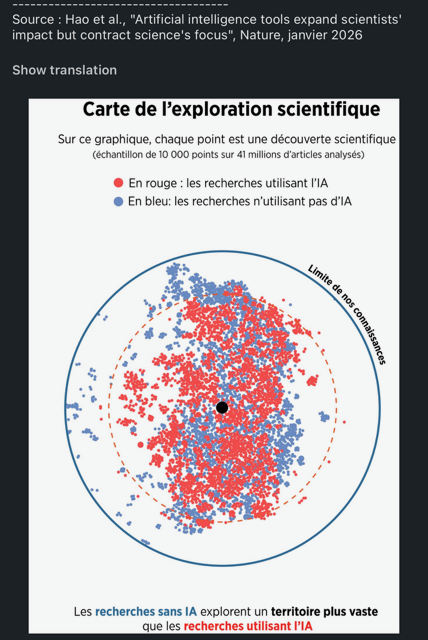

[Rock-Paper-Scissors](https://www.linkedin.com/posts/harleydavis_chatgpt-jeu-rocher-papier-ciseaux-activity-7422571009037299714-uXzE/)

## LinkedIn Profiles to follow

Interesting perspectives:

https://www.linkedin.com/in/gary-marcus-b6384b4/recent-activity/all/

https://www.linkedin.com/in/melanie-mitchell-08a04a6/recent-activity/all/

M. Mitchell has great content elsewhere too: https://aiguide.substack.com/p/llms-and-world-models-part-1

https://www.linkedin.com/in/msukhareva/recent-activity/all/

https://www.linkedin.com/in/gianlucamauro/recent-activity/all/

On Cyber, mostly:

https://www.linkedin.com/in/mirandarid/recent-activity/all/

https://www.linkedin.com/in/eito-miyamura-157305121/recent-activity/all/

## MEMEs

Unfortunately not sharing this until I gather authorization to share my collection of screenshots, although all of them are from public Internet (LinkedIn screenshots mostly). And it’s a pity because I have quite the collection of (gen-or-not)AI failures, etc. but that’s not for sharing until I can check whether it’s OK for me to do so… I insist: Even though ALL of it came from Internet-“freely-available” content.

And still, a few on LI you can follow for some fun content with sometimes memes on the topic…

E.g. Great for reasoning failures: https://www.linkedin.com/in/vincent-conitzer-2563082/recent-activity/all/

## Only for myself

Playing with MCP from code, in R, to get better acquainted:

https://modelcontextprotocol.io/docs/tools/inspector

(Will need a container (and spare time) for playing with these things…)

https://arman.aksoy.org/plumber2mcp/ & https://github.com/armish/plumber2mcp